# Risk Factor Analysis

## Outcome Variable

**Outcome Variable:** sstunted

## Predictor Variables

**Intervention Variable:** cleanck

**Adjustment Set:**

unadjusted

## Stratifying Variables

The analysis was stratified on these variable(s):

- agecat
- studyid
- country

## Data Summary

| agecat | studyid | country | cleanck | sstunted | n_cell | n |
| --- | --- | --- | --- | --- | --- | --- |
| Birth | CMC-V-BCS-2002 | INDIA | 1 | 0 | 38 | 92 |
| Birth | CMC-V-BCS-2002 | INDIA | 1 | 1 | 1 | 92 |
| Birth | CMC-V-BCS-2002 | INDIA | 0 | 0 | 50 | 92 |
| Birth | CMC-V-BCS-2002 | INDIA | 0 | 1 | 3 | 92 |
| Birth | GMS-Nepal | NEPAL | 1 | 0 | 9 | 621 |
| Birth | GMS-Nepal | NEPAL | 1 | 1 | 0 | 621 |
| Birth | GMS-Nepal | NEPAL | 0 | 0 | 584 | 621 |
| Birth | GMS-Nepal | NEPAL | 0 | 1 | 28 | 621 |
| Birth | IRC | INDIA | 1 | 0 | 209 | 378 |
| Birth | IRC | INDIA | 1 | 1 | 9 | 378 |
| Birth | IRC | INDIA | 0 | 0 | 154 | 378 |
| Birth | IRC | INDIA | 0 | 1 | 6 | 378 |
| Birth | MAL-ED | PERU | 1 | 0 | 1 | 2 |
| Birth | MAL-ED | PERU | 1 | 1 | 0 | 2 |
| Birth | MAL-ED | PERU | 0 | 0 | 1 | 2 |
| Birth | MAL-ED | PERU | 0 | 1 | 0 | 2 |
| Birth | NIH-Crypto | BANGLADESH | 1 | 0 | 342 | 561 |
| Birth | NIH-Crypto | BANGLADESH | 1 | 1 | 3 | 561 |
| Birth | NIH-Crypto | BANGLADESH | 0 | 0 | 210 | 561 |
| Birth | NIH-Crypto | BANGLADESH | 0 | 1 | 6 | 561 |
| Birth | PROVIDE | BANGLADESH | 1 | 0 | 436 | 539 |
| Birth | PROVIDE | BANGLADESH | 1 | 1 | 2 | 539 |
| Birth | PROVIDE | BANGLADESH | 0 | 0 | 99 | 539 |
| Birth | PROVIDE | BANGLADESH | 0 | 1 | 2 | 539 |
| 6 months | CMC-V-BCS-2002 | INDIA | 1 | 0 | 149 | 369 |
| 6 months | CMC-V-BCS-2002 | INDIA | 1 | 1 | 14 | 369 |
| 6 months | CMC-V-BCS-2002 | INDIA | 0 | 0 | 178 | 369 |
| 6 months | CMC-V-BCS-2002 | INDIA | 0 | 1 | 28 | 369 |
| 6 months | GMS-Nepal | NEPAL | 1 | 0 | 8 | 505 |
| 6 months | GMS-Nepal | NEPAL | 1 | 1 | 0 | 505 |
| 6 months | GMS-Nepal | NEPAL | 0 | 0 | 478 | 505 |
| 6 months | GMS-Nepal | NEPAL | 0 | 1 | 19 | 505 |
| 6 months | IRC | INDIA | 1 | 0 | 216 | 398 |
| 6 months | IRC | INDIA | 1 | 1 | 14 | 398 |
| 6 months | IRC | INDIA | 0 | 0 | 154 | 398 |
| 6 months | IRC | INDIA | 0 | 1 | 14 | 398 |
| 6 months | MAL-ED | SOUTH AFRICA | 1 | 0 | 1 | 1 |
| 6 months | MAL-ED | SOUTH AFRICA | 1 | 1 | 0 | 1 |
| 6 months | MAL-ED | SOUTH AFRICA | 0 | 0 | 0 | 1 |
| 6 months | MAL-ED | SOUTH AFRICA | 0 | 1 | 0 | 1 |
| 6 months | NIH-Crypto | BANGLADESH | 1 | 0 | 318 | 545 |
| 6 months | NIH-Crypto | BANGLADESH | 1 | 1 | 11 | 545 |
| 6 months | NIH-Crypto | BANGLADESH | 0 | 0 | 211 | 545 |
| 6 months | NIH-Crypto | BANGLADESH | 0 | 1 | 5 | 545 |
| 6 months | PROVIDE | BANGLADESH | 1 | 0 | 491 | 604 |
| 6 months | PROVIDE | BANGLADESH | 1 | 1 | 7 | 604 |
| 6 months | PROVIDE | BANGLADESH | 0 | 0 | 99 | 604 |
| 6 months | PROVIDE | BANGLADESH | 0 | 1 | 7 | 604 |
| 24 months | CMC-V-BCS-2002 | INDIA | 1 | 0 | 127 | 371 |
| 24 months | CMC-V-BCS-2002 | INDIA | 1 | 1 | 36 | 371 |
| 24 months | CMC-V-BCS-2002 | INDIA | 0 | 0 | 119 | 371 |
| 24 months | CMC-V-BCS-2002 | INDIA | 0 | 1 | 89 | 371 |
| 24 months | GMS-Nepal | NEPAL | 1 | 0 | 5 | 435 |
| 24 months | GMS-Nepal | NEPAL | 1 | 1 | 0 | 435 |
| 24 months | GMS-Nepal | NEPAL | 0 | 0 | 384 | 435 |
| 24 months | GMS-Nepal | NEPAL | 0 | 1 | 46 | 435 |
| 24 months | IRC | INDIA | 1 | 0 | 210 | 400 |
| 24 months | IRC | INDIA | 1 | 1 | 21 | 400 |
| 24 months | IRC | INDIA | 0 | 0 | 150 | 400 |
| 24 months | IRC | INDIA | 0 | 1 | 19 | 400 |
| 24 months | MAL-ED | SOUTH AFRICA | 1 | 0 | 1 | 1 |
| 24 months | MAL-ED | SOUTH AFRICA | 1 | 1 | 0 | 1 |
| 24 months | MAL-ED | SOUTH AFRICA | 0 | 0 | 0 | 1 |
| 24 months | MAL-ED | SOUTH AFRICA | 0 | 1 | 0 | 1 |
| 24 months | NIH-Crypto | BANGLADESH | 1 | 0 | 190 | 410 |
| 24 months | NIH-Crypto | BANGLADESH | 1 | 1 | 9 | 410 |
| 24 months | NIH-Crypto | BANGLADESH | 0 | 0 | 200 | 410 |
| 24 months | NIH-Crypto | BANGLADESH | 0 | 1 | 11 | 410 |
| 24 months | PROVIDE | BANGLADESH | 1 | 0 | 452 | 578 |
| 24 months | PROVIDE | BANGLADESH | 1 | 1 | 27 | 578 |
| 24 months | PROVIDE | BANGLADESH | 0 | 0 | 74 | 578 |
| 24 months | PROVIDE | BANGLADESH | 0 | 1 | 25 | 578 |

The following strata were considered:

- agecat: 24 months, studyid: CMC-V-BCS-2002, country: INDIA
- agecat: 24 months, studyid: GMS-Nepal, country: NEPAL
- agecat: 24 months, studyid: IRC, country: INDIA
- agecat: 24 months, studyid: MAL-ED, country: SOUTH AFRICA
- agecat: 24 months, studyid: NIH-Crypto, country: BANGLADESH
- agecat: 24 months, studyid: PROVIDE, country: BANGLADESH
- agecat: 6 months, studyid: CMC-V-BCS-2002, country: INDIA
- agecat: 6 months, studyid: GMS-Nepal, country: NEPAL
- agecat: 6 months, studyid: IRC, country: INDIA
- agecat: 6 months, studyid: MAL-ED, country: SOUTH AFRICA
- agecat: 6 months, studyid: NIH-Crypto, country: BANGLADESH
- agecat: 6 months, studyid: PROVIDE, country: BANGLADESH
- agecat: Birth, studyid: CMC-V-BCS-2002, country: INDIA
- agecat: Birth, studyid: GMS-Nepal, country: NEPAL
- agecat: Birth, studyid: IRC, country: INDIA
- agecat: Birth, studyid: MAL-ED, country: PERU
- agecat: Birth, studyid: NIH-Crypto, country: BANGLADESH
- agecat: Birth, studyid: PROVIDE, country: BANGLADESH

### Dropped Strata

Some strata were dropped due to rare outcomes:

- agecat: Birth, studyid: CMC-V-BCS-2002, country: INDIA
- agecat: Birth, studyid: GMS-Nepal, country: NEPAL
- agecat: Birth, studyid: MAL-ED, country: PERU
- agecat: Birth, studyid: NIH-Crypto, country: BANGLADESH
- agecat: Birth, studyid: PROVIDE, country: BANGLADESH
- agecat: 6 months, studyid: GMS-Nepal, country: NEPAL
- agecat: 6 months, studyid: MAL-ED, country: SOUTH AFRICA
- agecat: 24 months, studyid: GMS-Nepal, country: NEPAL
- agecat: 24 months, studyid: MAL-ED, country: SOUTH AFRICA

## Methods Detail

We’re interested in the causal parameters $E[Y_a]$ for all values of $a \in \mathcal{A}$. These parameters represent the mean outcome if, possibly contrary to fact, we intervened to set all units to have $A=a$. Under the randomization and positivity assumptions, these are identified by the statistical parameters $\psi_a=E_W[E_{Y|A,W}(Y|A=a,W)]$. In addition, we’re interested in the mean of $Y$, $E[Y]$ under no intervention (the observed mean). We will estimate these parameters by using SuperLearner to fit the relevant likelihood factors – $E_{Y|A,W}(Y|A=a,W)$ and $p(A=a|W)$, and then updating our likelihood fit using a joint TMLE.

For unadjusted analyses ($W=\{\}$), initial likelihoods were estimated using Lrnr_glm to estimate the simple $E(Y|A)$ and Lrnr_mean to estimate $p(A)$. For adjusted analyses, a small library containing Lrnr_glmnet, Lrnr_xgboost, and Lrnr_mean was used.

Having estimated these parameters, we will then use the delta method to estimate relative risks and attributable risks relative to a prespecified baseline level of $A$.

# Results Detail

## Results Plots

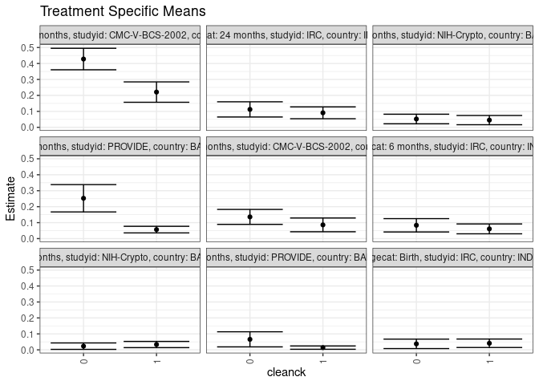

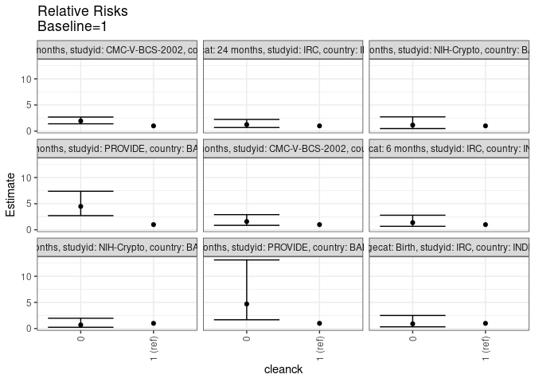

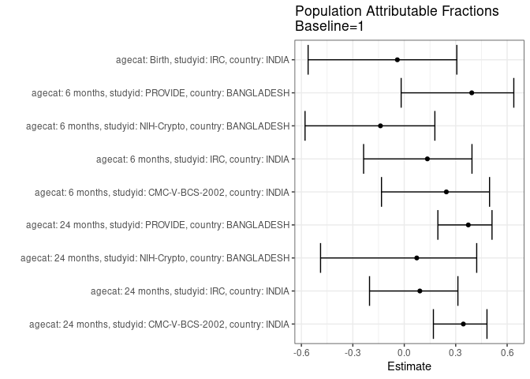

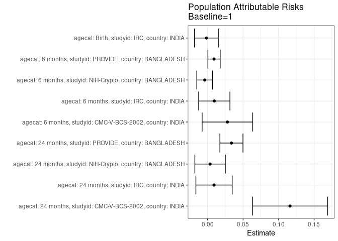

## Results Table

### Parameter: TSM

| agecat | studyid | country | intervention_level | baseline_level | estimate | ci_lower | ci_upper |
| --- | --- | --- | --- | --- | --- | --- | --- |
| Birth | IRC | INDIA | 1 | NA | 0.0412844 | 0.0148400 | 0.0677288 |
| Birth | IRC | INDIA | 0 | NA | 0.0375000 | 0.0080233 | 0.0669767 |
| 6 months | CMC-V-BCS-2002 | INDIA | 1 | NA | 0.0858896 | 0.0428158 | 0.1289634 |
| 6 months | CMC-V-BCS-2002 | INDIA | 0 | NA | 0.1359223 | 0.0890598 | 0.1827848 |
| 6 months | IRC | INDIA | 1 | NA | 0.0608696 | 0.0299315 | 0.0918077 |
| 6 months | IRC | INDIA | 0 | NA | 0.0833333 | 0.0414872 | 0.1251794 |
| 6 months | NIH-Crypto | BANGLADESH | 1 | NA | 0.0334347 | 0.0139917 | 0.0528776 |
| 6 months | NIH-Crypto | BANGLADESH | 0 | NA | 0.0231481 | 0.0030761 | 0.0432202 |
| 6 months | PROVIDE | BANGLADESH | 1 | NA | 0.0140562 | 0.0037083 | 0.0244042 |
| 6 months | PROVIDE | BANGLADESH | 0 | NA | 0.0660377 | 0.0187209 | 0.1133546 |
| 24 months | CMC-V-BCS-2002 | INDIA | 1 | NA | 0.2208589 | 0.1570904 | 0.2846273 |
| 24 months | CMC-V-BCS-2002 | INDIA | 0 | NA | 0.4278846 | 0.3605548 | 0.4952145 |
| 24 months | IRC | INDIA | 1 | NA | 0.0909091 | 0.0537904 | 0.1280278 |
| 24 months | IRC | INDIA | 0 | NA | 0.1124260 | 0.0647408 | 0.1601113 |
| 24 months | NIH-Crypto | BANGLADESH | 1 | NA | 0.0452261 | 0.0163195 | 0.0741327 |
| 24 months | NIH-Crypto | BANGLADESH | 0 | NA | 0.0521327 | 0.0221020 | 0.0821634 |
| 24 months | PROVIDE | BANGLADESH | 1 | NA | 0.0563674 | 0.0356959 | 0.0770389 |
| 24 months | PROVIDE | BANGLADESH | 0 | NA | 0.2525253 | 0.1668694 | 0.3381811 |

### Parameter: E(Y)

| agecat | studyid | country | intervention_level | baseline_level | estimate | ci_lower | ci_upper |
| --- | --- | --- | --- | --- | --- | --- | --- |
| Birth | IRC | INDIA | NA | NA | 0.0396825 | 0.0199772 | 0.0593879 |
| 6 months | CMC-V-BCS-2002 | INDIA | NA | NA | 0.1138211 | 0.0813725 | 0.1462698 |
| 6 months | IRC | INDIA | NA | NA | 0.0703518 | 0.0451953 | 0.0955082 |
| 6 months | NIH-Crypto | BANGLADESH | NA | NA | 0.0293578 | 0.0151725 | 0.0435431 |
| 6 months | PROVIDE | BANGLADESH | NA | NA | 0.0231788 | 0.0111688 | 0.0351888 |
| 24 months | CMC-V-BCS-2002 | INDIA | NA | NA | 0.3369272 | 0.2887662 | 0.3850883 |
| 24 months | IRC | INDIA | NA | NA | 0.1000000 | 0.0705637 | 0.1294363 |
| 24 months | NIH-Crypto | BANGLADESH | NA | NA | 0.0487805 | 0.0279044 | 0.0696566 |
| 24 months | PROVIDE | BANGLADESH | NA | NA | 0.0899654 | 0.0666186 | 0.1133122 |

### Parameter: RR

| agecat | studyid | country | intervention_level | baseline_level | estimate | ci_lower | ci_upper |
| --- | --- | --- | --- | --- | --- | --- | --- |
| Birth | IRC | INDIA | 1 | 1 | 1.0000000 | 1.0000000 | 1.000000 |
| Birth | IRC | INDIA | 0 | 1 | 0.9083333 | 0.3295172 | 2.503874 |
| 6 months | CMC-V-BCS-2002 | INDIA | 1 | 1 | 1.0000000 | 1.0000000 | 1.000000 |
| 6 months | CMC-V-BCS-2002 | INDIA | 0 | 1 | 1.5825243 | 0.8610851 | 2.908404 |
| 6 months | IRC | INDIA | 1 | 1 | 1.0000000 | 1.0000000 | 1.000000 |
| 6 months | IRC | INDIA | 0 | 1 | 1.3690476 | 0.6700696 | 2.797159 |
| 6 months | NIH-Crypto | BANGLADESH | 1 | 1 | 1.0000000 | 1.0000000 | 1.000000 |
| 6 months | NIH-Crypto | BANGLADESH | 0 | 1 | 0.6923401 | 0.2437201 | 1.966743 |
| 6 months | PROVIDE | BANGLADESH | 1 | 1 | 1.0000000 | 1.0000000 | 1.000000 |
| 6 months | PROVIDE | BANGLADESH | 0 | 1 | 4.6981132 | 1.6817875 | 13.124290 |
| 24 months | CMC-V-BCS-2002 | INDIA | 1 | 1 | 1.0000000 | 1.0000000 | 1.000000 |
| 24 months | CMC-V-BCS-2002 | INDIA | 0 | 1 | 1.9373665 | 1.3944575 | 2.691648 |
| 24 months | IRC | INDIA | 1 | 1 | 1.0000000 | 1.0000000 | 1.000000 |
| 24 months | IRC | INDIA | 0 | 1 | 1.2366864 | 0.6863932 | 2.228159 |
| 24 months | NIH-Crypto | BANGLADESH | 1 | 1 | 1.0000000 | 1.0000000 | 1.000000 |
| 24 months | NIH-Crypto | BANGLADESH | 0 | 1 | 1.1527120 | 0.4875719 | 2.725229 |
| 24 months | PROVIDE | BANGLADESH | 1 | 1 | 1.0000000 | 1.0000000 | 1.000000 |
| 24 months | PROVIDE | BANGLADESH | 0 | 1 | 4.4799850 | 2.7184882 | 7.382878 |

### Parameter: PAR

| agecat | studyid | country | intervention_level | baseline_level | estimate | ci_lower | ci_upper |
| --- | --- | --- | --- | --- | --- | --- | --- |
| Birth | IRC | INDIA | 1 | NA | -0.0016019 | -0.0183649 | 0.0151612 |
| 6 months | CMC-V-BCS-2002 | INDIA | 1 | NA | 0.0279316 | -0.0076931 | 0.0635563 |
| 6 months | IRC | INDIA | 1 | NA | 0.0094822 | -0.0125119 | 0.0314763 |
| 6 months | NIH-Crypto | BANGLADESH | 1 | NA | -0.0040769 | -0.0151603 | 0.0070066 |
| 6 months | PROVIDE | BANGLADESH | 1 | NA | 0.0091226 | 0.0004771 | 0.0177681 |
| 24 months | CMC-V-BCS-2002 | INDIA | 1 | NA | 0.1160683 | 0.0630333 | 0.1691034 |
| 24 months | IRC | INDIA | 1 | NA | 0.0090909 | -0.0164617 | 0.0346435 |
| 24 months | NIH-Crypto | BANGLADESH | 1 | NA | 0.0035544 | -0.0178995 | 0.0250082 |
| 24 months | PROVIDE | BANGLADESH | 1 | NA | 0.0335980 | 0.0173456 | 0.0498504 |

### Parameter: PAF

| agecat | studyid | country | intervention_level | baseline_level | estimate | ci_lower | ci_upper |
| --- | --- | --- | --- | --- | --- | --- | --- |
| Birth | IRC | INDIA | 1 | NA | -0.0403670 | -0.5607939 | 0.3065302 |
| 6 months | CMC-V-BCS-2002 | INDIA | 1 | NA | 0.2453988 | -0.1328865 | 0.4973698 |
| 6 months | IRC | INDIA | 1 | NA | 0.1347826 | -0.2371455 | 0.3948965 |
| 6 months | NIH-Crypto | BANGLADESH | 1 | NA | -0.1388678 | -0.5787290 | 0.1784405 |
| 6 months | PROVIDE | BANGLADESH | 1 | NA | 0.3935743 | -0.0181345 | 0.6387981 |
| 24 months | CMC-V-BCS-2002 | INDIA | 1 | NA | 0.3444908 | 0.1698651 | 0.4823825 |
| 24 months | IRC | INDIA | 1 | NA | 0.0909091 | -0.2026600 | 0.3128180 |
| 24 months | NIH-Crypto | BANGLADESH | 1 | NA | 0.0728643 | -0.4882985 | 0.4224408 |
| 24 months | PROVIDE | BANGLADESH | 1 | NA | 0.3734543 | 0.1960278 | 0.5117250 |